# Introduction

Dataset: Red wine Observations: 1599 Variables: 12

I chose the wine quality dataset because I like wine, and I’ve made some python scripts to this dataset before.

Using the statistical language R, I’m going to answer the sample guiding question: Which chemical properties influence the quality of red wines?

I’m going to use the knowlege gained from the Udacity R programming lessons to showcase my results.

The first step after loading the libraries, the directory, and the database, will be discovering the structure and the classes in the dataset

```
## 'data.frame':    1599 obs. of  12 variables:
##  $ fixed acidity       : num  7.4 7.8 7.8 11.2 7.4 7.4 7.9 7.3 7.8 7.5 ...
##  $ volatile acidity    : num  0.7 0.88 0.76 0.28 0.7 0.66 0.6 0.65 0.58 0.5 ...
##  $ citric acid         : num  0 0 0.04 0.56 0 0 0.06 0 0.02 0.36 ...
##  $ residual sugar      : num  1.9 2.6 2.3 1.9 1.9 1.8 1.6 1.2 2 6.1 ...
##  $ chlorides           : num  0.076 0.098 0.092 0.075 0.076 0.075 0.069 0.065 0.073 0.071 ...
##  $ free sulfur dioxide : num  11 25 15 17 11 13 15 15 9 17 ...
##  $ total sulfur dioxide: num  34 67 54 60 34 40 59 21 18 102 ...
##  $ density             : num  0.998 0.997 0.997 0.998 0.998 ...
##  $ pH                  : num  3.51 3.2 3.26 3.16 3.51 3.51 3.3 3.39 3.36 3.35 ...
##  $ sulphates           : num  0.56 0.68 0.65 0.58 0.56 0.56 0.46 0.47 0.57 0.8 ...
##  $ alcohol             : num  9.4 9.8 9.8 9.8 9.4 9.4 9.4 10 9.5 10.5 ...
##  $ quality             : int  5 5 5 6 5 5 5 7 7 5 ...
```

As shown above, the dataset classes consist of mainly num or in python, floats, with the exeption of quality.

The question I’ve decided to explore is: -Which chemical properties have a statically significant correlation to the quality of wine?

I chose this question because quality is the only qualitative variable, so comparing the quantitative variables will have the most interesting conclusion.

In this cell, I’m changing the empty spaces in the title with “_" in order to not come up with errors in later code

```
##  fixed_acidity   volatile_acidity  citric_acid    residual_sugar
##  Min.   : 4.60   Min.   :0.1200   Min.   :0.000   Min.   : 0.900
##  1st Qu.: 7.10   1st Qu.:0.3900   1st Qu.:0.090   1st Qu.: 1.900
##  Median : 7.90   Median :0.5200   Median :0.260   Median : 2.200
##  Mean   : 8.32   Mean   :0.5278   Mean   :0.271   Mean   : 2.539
##  3rd Qu.: 9.20   3rd Qu.:0.6400   3rd Qu.:0.420   3rd Qu.: 2.600
##  Max.   :15.90   Max.   :1.5800   Max.   :1.000   Max.   :15.500
##    chlorides       free_sulfur_dioxide total_sulfur_dioxide
##  Min.   :0.01200   Min.   : 1.00       Min.   :  6.00
##  1st Qu.:0.07000   1st Qu.: 7.00       1st Qu.: 22.00
##  Median :0.07900   Median :14.00       Median : 38.00
##  Mean   :0.08747   Mean   :15.87       Mean   : 46.47
##  3rd Qu.:0.09000   3rd Qu.:21.00       3rd Qu.: 62.00
##  Max.   :0.61100   Max.   :72.00       Max.   :289.00
##     density             pH          sulphates         alcohol
##  Min.   :0.9901   Min.   :2.740   Min.   :0.3300   Min.   : 8.40
##  1st Qu.:0.9956   1st Qu.:3.210   1st Qu.:0.5500   1st Qu.: 9.50
##  Median :0.9968   Median :3.310   Median :0.6200   Median :10.20
##  Mean   :0.9967   Mean   :3.311   Mean   :0.6581   Mean   :10.42
##  3rd Qu.:0.9978   3rd Qu.:3.400   3rd Qu.:0.7300   3rd Qu.:11.10
##  Max.   :1.0037   Max.   :4.010   Max.   :2.0000   Max.   :14.90
##     quality
##  Min.   :3.000
##  1st Qu.:5.000
##  Median :6.000
##  Mean   :5.636
##  3rd Qu.:6.000
##  Max.   :8.000
```

Although quality is a scale from 1-10, this data set only has quality in a range of 3-8.

# Univariate Plots Section

```
##   fixed_acidity volatile_acidity citric_acid residual_sugar chlorides
## 1           7.4             0.70        0.00            1.9     0.076
## 2           7.8             0.88        0.00            2.6     0.098
## 3           7.8             0.76        0.04            2.3     0.092
## 4          11.2             0.28        0.56            1.9     0.075
## 5           7.4             0.70        0.00            1.9     0.076
## 6           7.4             0.66        0.00            1.8     0.075
##   free_sulfur_dioxide total_sulfur_dioxide density   pH sulphates alcohol
## 1                  11                   34  0.9978 3.51      0.56     9.4
## 2                  25                   67  0.9968 3.20      0.68     9.8
## 3                  15                   54  0.9970 3.26      0.65     9.8
## 4                  17                   60  0.9980 3.16      0.58     9.8
## 5                  11                   34  0.9978 3.51      0.56     9.4
## 6                  13                   40  0.9978 3.51      0.56     9.4
##   quality
## 1       5
## 2       5
## 3       5
## 4       6
## 5       5
## 6       5
```

# Univariate Plots

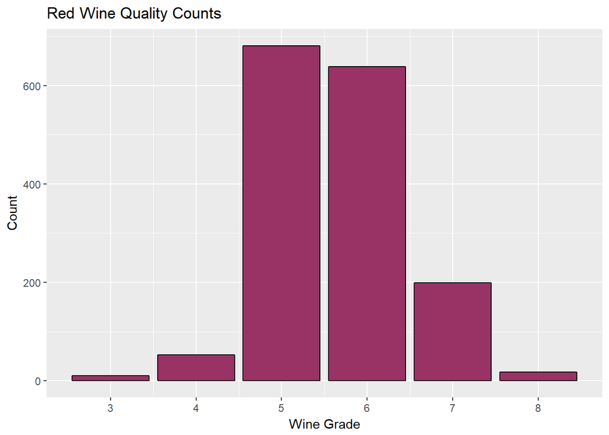

This chart shows the counts of the different quality levels of red wine. It appears that majorities of the wines have a quality level of either 5 or 6. This might create problems later on being that there might not be enough data to find trends outside of these levels.

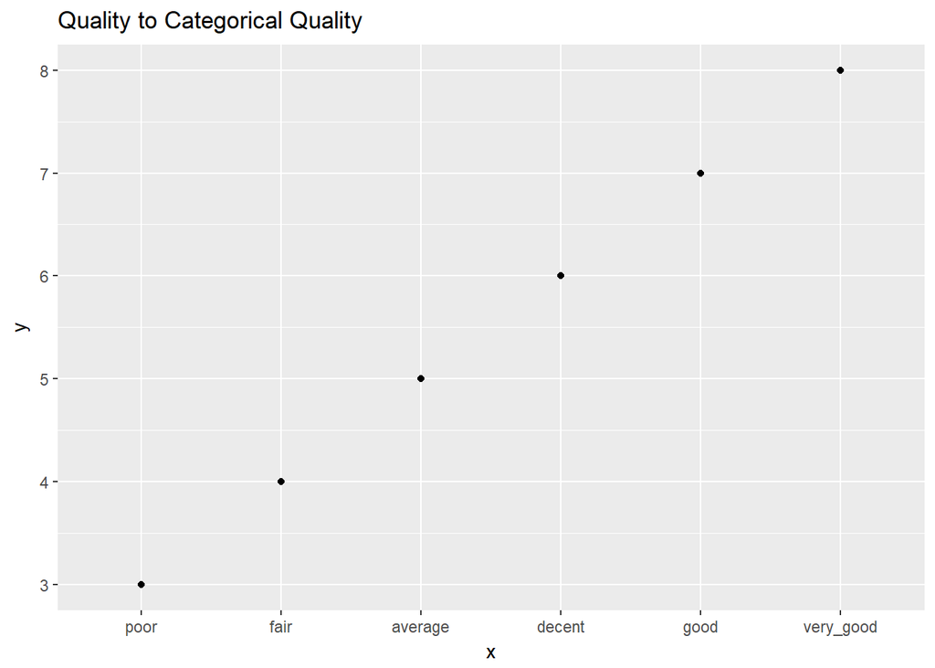

I created a categorical quality variable to explain how I define each quality level from 3-8.

```
##   fixed_acidity volatile_acidity citric_acid residual_sugar chlorides
## 1           7.4             0.70        0.00            1.9     0.076
## 2           7.8             0.88        0.00            2.6     0.098
## 3           7.8             0.76        0.04            2.3     0.092
## 4          11.2             0.28        0.56            1.9     0.075
## 5           7.4             0.70        0.00            1.9     0.076
## 6           7.4             0.66        0.00            1.8     0.075
##   free_sulfur_dioxide total_sulfur_dioxide density   pH sulphates alcohol
## 1                  11                   34  0.9978 3.51      0.56     9.4
## 2                  25                   67  0.9968 3.20      0.68     9.8
## 3                  15                   54  0.9970 3.26      0.65     9.8
## 4                  17                   60  0.9980 3.16      0.58     9.8
## 5                  11                   34  0.9978 3.51      0.56     9.4
## 6                  13                   40  0.9978 3.51      0.56     9.4
##   quality
## 1       5
## 2       5
## 3       5
## 4       6
## 5       5
## 6       5
```

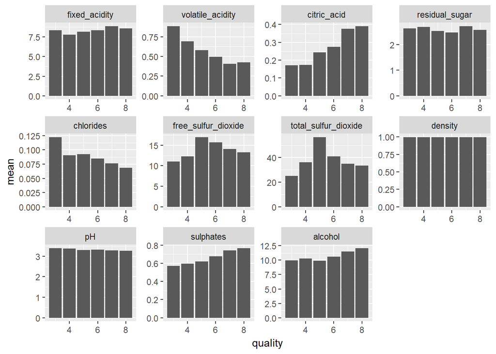

These charts show the means of each quality levels chemical properties.

Although the charts arent the easiest to read because they are so small, I chose to do it this way so I could get a basic idea of which chemical properties might have a correlation with quality.

Here, it appears that there may be a negative correlation between: -volatile acidity and chlorides

In the positive, there is: -citric acid, sulphates, and alcohol

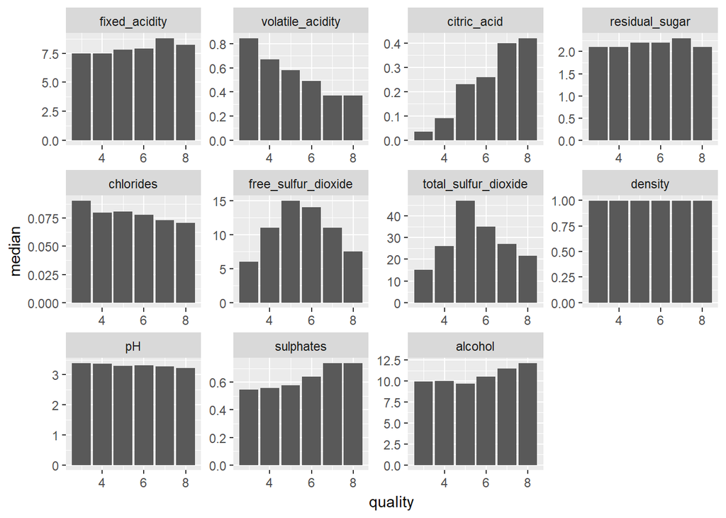

I also chose to do the median to see if there was much of a difference with the outliers taken out.

The charts seem similar, but citric acid seems that without it’s outliers, there may be a stronger correlation.

Chemical Property Distribution

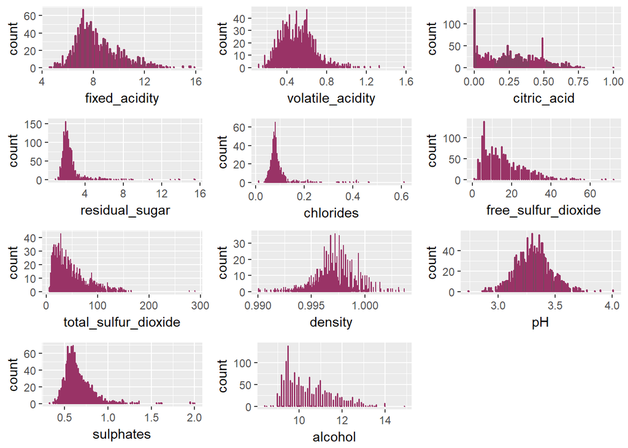

Again, I chose to facet wrap just because I wanted to see if the values were normally distributed.

Chlorides and residual sugar seem to have some outliers, so I’ll take the log10 of them so I create a more accurate distribution

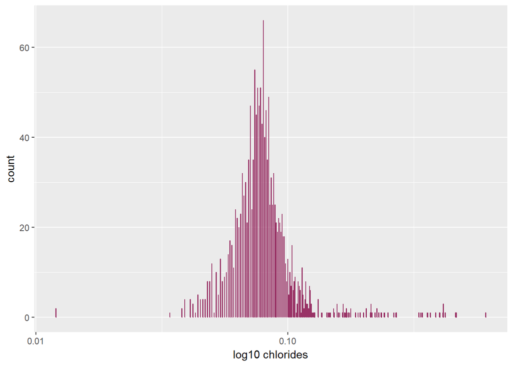

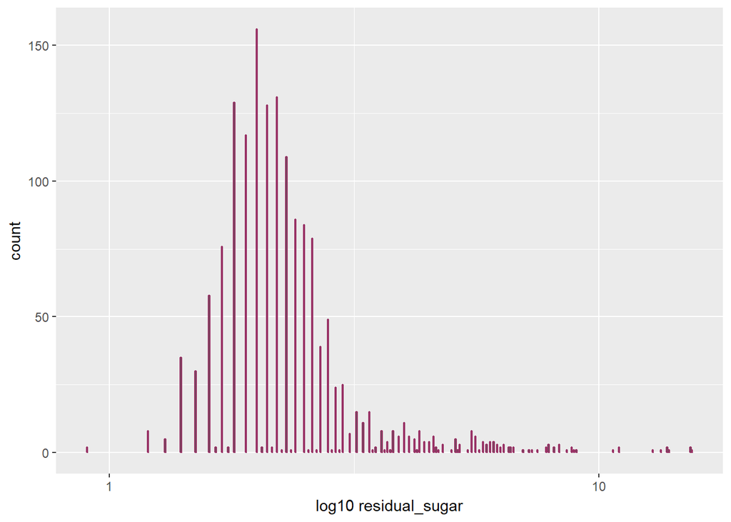

# Multivariate Plots

I chose to make the following charts to see which chemical properties to focus on.

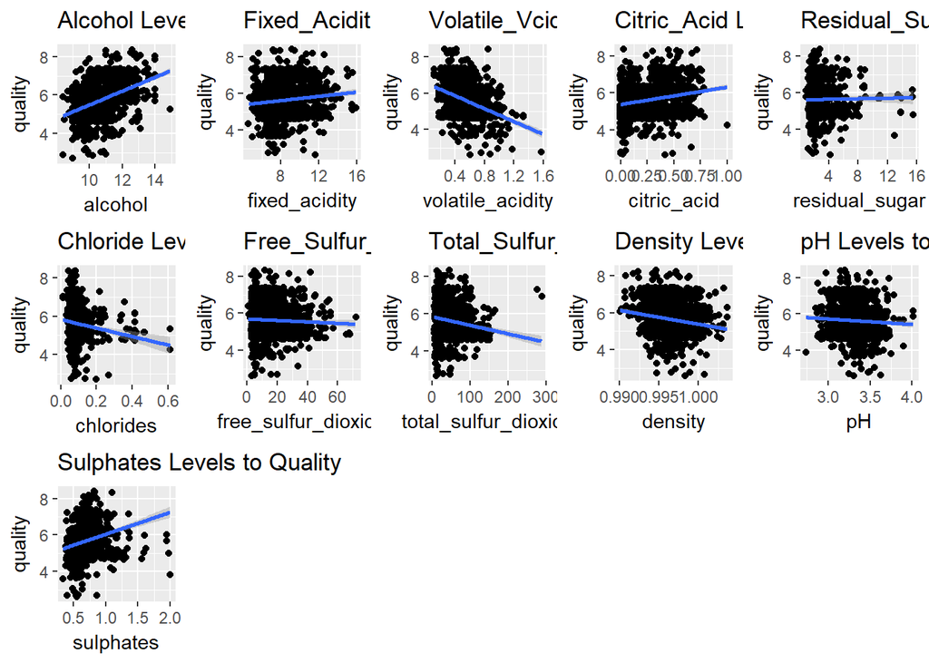

By taking a quick look at these charts, I can see which chemical properties appear to have more effect on quality. In order to make it easier on the eyes, I will split up the charts into 3 groups: positive_trends, neutral_trends, and negative_trends

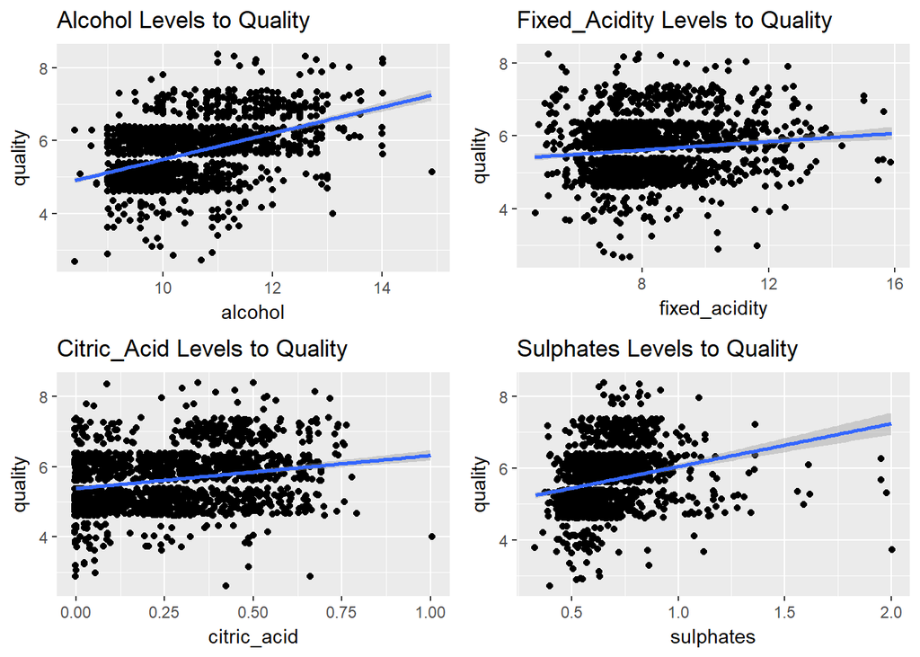

These carts show the chemical properties that visually seem more likely to to effect quality in a positive direction, meaning that there is more of a positive correlation between the chemical property and the quality

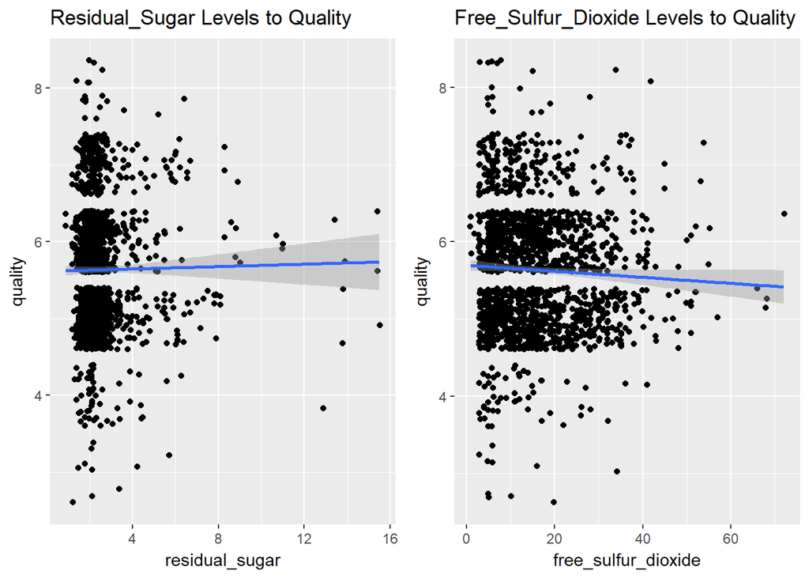

These carts show the chemical properties that visually seem more likely to to effect quality in a neutral direction, meaning that there is probably not much correlation between the chemical property and the quality

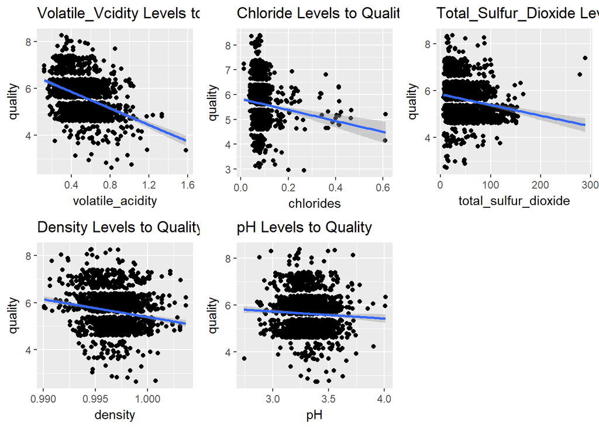

These carts show the chemical properties that visually seem more likely to to effect quality in a negative direction, meaning that there is more of a negative correlation between the chemical property and the quality

Although visually there seems to be a correlation, calculations still need to be made to see if the correlation is statistically significant enough to draw any conclusions.

# Final Plots

I’m going to choose the plots that stand out the most of having more of a positive/negative impact on quality:

positive: Alcohol Sulphates

negative: Volitile_Acidity Chloride

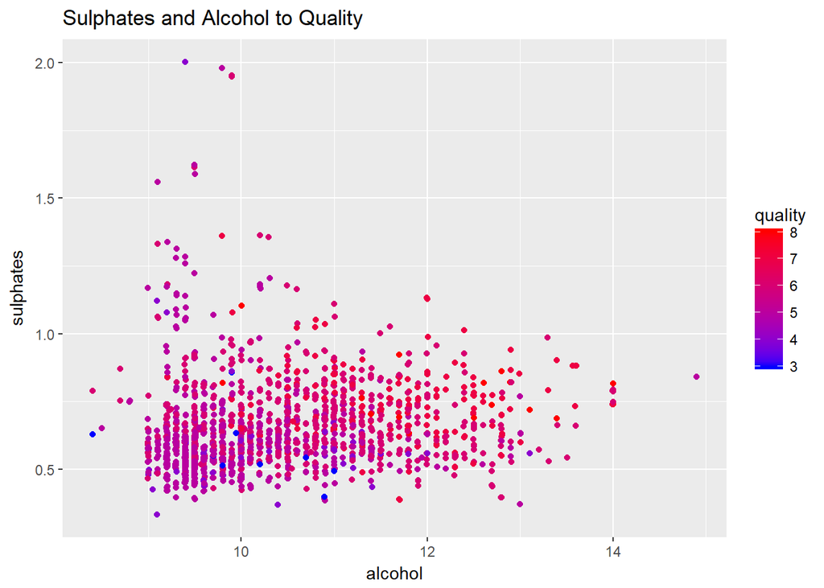

As expected, there is visual evidence that higher Sulphate and Alcohol levels appear by number to lean more towards the higher quality direction.

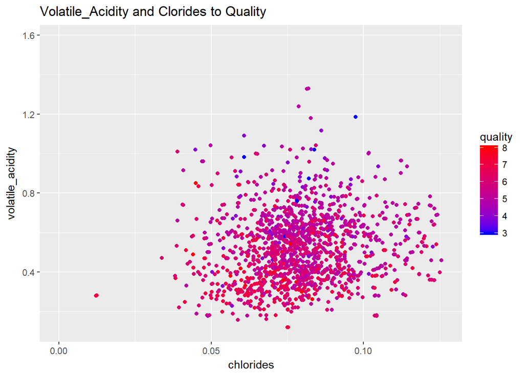

As expected, there is visual evidence that higher Volatile_Acidity and Chloride levels appear by number to lean more towards the lower quality direction.

My final plot will show the correlations between quality and all of the chemical properties to see if my assumptions were right.

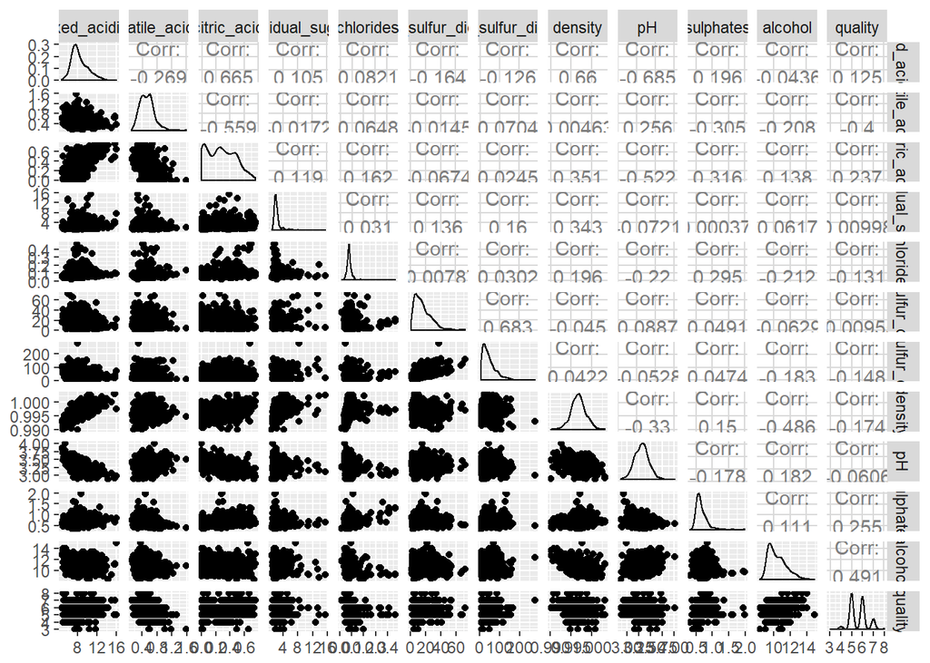

# Summary

These are the correlations to quality that I discovered (from high to low):

1. alcohol +.491
2. volitile acidity -.4
3. sulphates +.255
4. citric acid +.237
5. density -.174
6. total sulfur dioxide -.148
7. chlorides -.131
8. fixed acidity .125
9. pH -.0606
10. residual sugar .00998
11. free sulfur dioxide -.00955

# Reflection

I’d say that there is evidence for correlation on everything above density: 1-4.

Although through my previous visual observations, I had originally thought that chloride levels would have a stronger effect on quality, it doesn’t seems less significant than I had hypothesised.

Since most of the wine data had a quality level of 5 and 6, my data might have shown a more stronger correlation of the chemical properties if it had contained more data from the lower and the higher levels. If I were to do an analysis again, I would try to find more examples of higher and lower quality wines.

On a last note, quality is qualitative, so it depends on human oppinion. Therefore, even if professionals were in charge of deciding the levels of quality, it’s still dependant on human opinion.